# Epigenetic NicheNet

Klara Dewitte

2022-11-28

```r
library(limma)
library(edgeR)
library(stringr)
library(tidyverse)
library(dplyr)
library(nichenetr)
library(biomaRt)
library(data.table)
library(stringr)
library(synapser)
```

```r
library(knitr)
library(ggstatsplot)
library(cowplot)
library(annotables)
library(viridis)
memory.limit(size = 3000000)
```

```
## [1] 3e+06
```

```r
knitr::opts_chunk$set(error = TRUE)
```

```r
# NicheNet default networks
lr_network <- readRDS(url("https://zenodo.org/record/7074291/files/lr_network_human_21122021.rds"))
sig_network <- readRDS(url("https://zenodo.org/record/7074291/files/signaling_network_human_21122021.rds"))
gr_network <- readRDS(url("https://zenodo.org/record/7074291/files/gr_network_human_21122021.rds"))
ligand_target_matrix <- readRDS(url("https://zenodo.org/record/7074291/files/ligand_target_matrix_nsga2r_final.rds"))
```

## Check 1. NicheNet genes and Ananse genes

First, we will load in an appropriate GRN network by Ananse and NicheNet v2’s prior model to verify that there is no issue there with the correspondence of the gene names.

```r
ligand_target_matrix[1:5,1:5] # target genes in rows, ligands in columns
```

```
##                     A2M        AANAT        ABCA1          ACE        ACE2
## A-GAMMA3'E 0.0000000000 0.0000000000 0.0000000000 0.0000000000 0.000000000
## A1BG       0.0018503922 0.0011108718 0.0014225077 0.0028594037 0.001139013
## A1BG-AS1   0.0007400797 0.0004677614 0.0005193137 0.0007836698 0.000375007
## A1CF       0.0024799266 0.0013026348 0.0020420890 0.0047921048 0.003273375
## A2M        0.0084693452 0.0040689323 0.0064256379 0.0105191365 0.005719199
```

```r
targets.NN <- unique(rownames(ligand_target_matrix))
length(targets.NN) #33354
```

```
## [1] 33354
```

```r
head(targets.NN,10)
```

```
##  [1] "A-GAMMA3'E" "A1BG"       "A1BG-AS1"   "A1CF"       "A2M"
##  [6] "A2M-AS1"    "A2ML1"      "A2MP1"      "A3GALT2"    "A4GALT"
```

```r
# loading in some GRN network
# rp_LINCS_MCF10A_EGF_24_grn.txt
test.GRN <- read.delim2("C:/Users/klara/MaStat/Thesis/GithubThesis/Thesis_NicheNet/Ananse_networks/GRN/LINCS_MCF10A_EGF_24_NO_RNAseq_grn.txt", header = TRUE, sep = ";")
targets.GRN <- unique(test.GRN$to) # 36115 target genes
length(targets.GRN) #32495
```

```
## [1] 32495
```

```r
head(targets.GRN)
```

```
## [1] "A3GALT2"     "AARS2"       "ABALON"      "ABCC5-AS1"   "ABCF2-H2BK1"
## [6] "ABHD15-AS1"
```

```r
# checking the overlap
length(intersect(targets.NN,targets.GRN)) #3453
```

```
## [1] 3453
```

```r
head(setdiff(targets.NN,targets.GRN),10)
```

```
##  [1] "A-GAMMA3'E" "A1BG"       "A1BG-AS1"   "A1CF"       "A2M"
##  [6] "A2M-AS1"    "A2ML1"      "A2MP1"      "A4GALT"     "A4GNT"
```

```r
head(setdiff(targets.GRN,targets.NN),10)
```

```
##  [1] "ABCF2-H2BK1"  "ABHD15-AS1"   "ACAP2-IT1"    "ACSL3-AS1"    "ACSL6-AS1"
##  [6] "ACTBP11"      "ADAMTSL4-AS2" "ADGRL1-AS1"   "ADI1P1"       "ADI1P2"
```

## Check 2: RNA gene annotations

```r
# login of synapsr
synLogin('KlaraDewitte','Thesis2022')
```

```r
# Obtain a pointer and download the RNA-seq level 1 data
syn18508389 <- synGet(entity = 'syn18508389')
```

```
## Welcome, KlaraDewitte!
```

```r
filepath_RNA <- syn18508389$path
rawdata <- read.csv(filepath_RNA, row.names = 1)

# Obtain pointer and download metadata
ssyn15574180 <- synGet(entity = 'syn15574180')
filepath_metadata <- ssyn15574180$path
metadata <- read.csv(filepath_metadata)

# Obtain pointer and download RNA gene annotations
syn18779231 <- synGet(entity = 'syn18779231')
filepath_annotations <- syn18779231$path
rna.annot <- read.csv(filepath_annotations)
targets.RNA <- unique(rna.annot$hgnc_symbol)

# how many unique human genes do we have?
length(targets.RNA) #37263
```

```
## [1] 37263
```

```r
# checking the overlap
length(intersect(targets.NN, targets.RNA)) # also reasonable 27618
```

```
## [1] 27618
```

```r
length(intersect(targets.GRN, targets.RNA)) # very high 5013
```

```
## [1] 5013
```

```r
length(intersect(intersect(targets.NN,targets.GRN)
                 , targets.RNA)) # very reasonable 3352
```

```
## [1] 3352
```

```r
# Obtain subset of metadata and RNA-seq data for 24h
values <- stringr::str_split(metadata$specimenName, "_") %>%
                  do.call(rbind, .)

id <- metadata[which(metadata$RNAseq_QCpass == TRUE & metadata$secondLigand == "none") ,]$specimenID
rawdata_subset <- rawdata[,which(colnames(rawdata) %in% id)]
metadata_subset <- metadata[which(metadata$specimenID %in% id),]

ensembl <- useEnsembl(biomart = "ensembl", dataset = "hsapiens_gene_ensembl")
```

We have noticed that they made a gene annotation file available, but there migth be some issues with that. There are also seem a lot of genes. The counts were summed at the gene level, but maybe irrelevant genes. So let’s first check how good the conversion is and if we need to adapt it.  
We did get a link for a new annotation package that could help check this. https://github.com/stephenturner/annotables  
We can annotate more genes and the missing ones don’t seem to have a gene symbol.

```r
# so we have a lot of missing gene symbols and 23 dupblicates in the symbols
sum(is.na(rna.annot$hgnc_symbol))
```

```
## [1] 20082
```

```r
sum(is.na(rna.annot$ensembl_gene_id))
```

```
## [1] 0
```

```r
sum(duplicated(na.omit(rna.annot$hgnc_symbol)))
```

```
## [1] 23
```

```r
length(rna.annot$ensembl_gene_id)
```

```
## [1] 57367
```

```r
sum(is.na(rna.annot$hgnc_symbol)) + sum(duplicated(na.omit(rna.annot$hgnc_symbol))) +
  length(unique(rna.annot$hgnc_symbol)) # one gene too much
```

```
## [1] 57368
```

```r
# some consistency checks of gene symbols that should be there
"MRC2" %in% rna.annot$hgnc_symbol
```

```
## [1] FALSE
```

```r
"OSBPL7" %in% rna.annot$hgnc_symbol
```

```
## [1] FALSE
```

```r
#new package
# how can we use it? use only protein coding genes
head(grch37)
```

```
## # A tibble: 6 x 9
##   ensgene         entrez symbol   chr    start    end strand biotype description
##   <chr>            <int> <chr>    <chr>  <int>  <int>  <int> <chr>   <chr>
## 1 ENSG00000000003   7105 TSPAN6   X     9.99e7 9.99e7     -1 protei~ tetraspani~
## 2 ENSG00000000005  64102 TNMD     X     9.98e7 9.99e7      1 protei~ tenomodulin
## 3 ENSG00000000419   8813 DPM1     20    4.96e7 4.96e7     -1 protei~ dolichyl-p~
## 4 ENSG00000000457  57147 SCYL3    1     1.70e8 1.70e8     -1 protei~ SCY1-like ~
## 5 ENSG00000000460  55732 C1orf112 1     1.70e8 1.70e8      1 protei~ chromosome~
## 6 ENSG00000000938   2268 FGR      1     2.79e7 2.80e7     -1 protei~ feline Gar~
```

```r
head(grch38)
```

```
## # A tibble: 6 x 9
##   ensgene         entrez symbol   chr    start    end strand biotype description
##   <chr>            <int> <chr>    <chr>  <int>  <int>  <int> <chr>   <chr>
## 1 ENSG00000000003   7105 TSPAN6   X     1.01e8 1.01e8     -1 protei~ tetraspani~
## 2 ENSG00000000005  64102 TNMD     X     1.01e8 1.01e8      1 protei~ tenomodulin
## 3 ENSG00000000419   8813 DPM1     20    5.09e7 5.10e7     -1 protei~ dolichyl-p~
## 4 ENSG00000000457  57147 SCYL3    1     1.70e8 1.70e8     -1 protei~ SCY1 like ~
## 5 ENSG00000000460  55732 C1orf112 1     1.70e8 1.70e8      1 protei~ chromosome~
## 6 ENSG00000000938   2268 FGR      1     2.76e7 2.76e7     -1 protei~ FGR proto-~
```

```r
colnames(rna.annot) <- c("ensgene", "mdd_annot_symbol")

# based on what we see here, grch38
# annot.37 <- inner_join(annots, grch37)
# length(unique(annot.38$ensgene))
annot.38 <- inner_join(rna.annot, grch38)
length(unique(annot.38$ensgene))
```

```
## [1] 57041
```

```r
"OSBPL7" %in% annot.38$symbol
```

```
## [1] TRUE
```

```r
"MRC2" %in% annot.38$symbol
```

```
## [1] TRUE
```

```r
sum(is.na(annot.38$ensgene))
```

```
## [1] 0
```

```r
sum(is.na(annot.38$mdd_annot_symbol))
```

```
## [1] 20230
```

```r
sum(is.na(annot.38$symbol))
```

```
## [1] 0
```

```r
# we could certainly use the biotype to filter out some of the genes
# for now just check the names
rna.annot <- dplyr::select(annot.38, ensgene, symbol,biotype) %>%
  unique()
```

## Check 3: RNA DE analysis

Now let’s focus on one DE analysis for EGF at 24 hours. The sample should pass the QC and the second ligand should be none. We are going to make a general DE model with all relevant ligands we could use and make a contrast for (1) each ligand and (2) each timepoint with respect to PBS at the same timepoint.

```r
# Get unique values of each cytokine, timepoint and replicate
unique_values <- values %>%
                  apply(2, unique) %>%
                  setNames(c("cytokine", "timepoint", "collection", "replicate"))

rawdata_subset$ensgene <- rownames(rawdata_subset) #convert rownames (genes) to a column

# create the subset of samples for the count matrix
# ensure that the gene symbols match with the counts
colnames(rawdata_subset)[ncol(rawdata_subset)] <- colnames(rna.annot)[1]
counts <- dplyr::left_join(rawdata_subset, rna.annot) %>%
  dplyr::select(c(colnames(rna.annot), all_of(id)))
gene.annot <- colnames(counts)[1:2]

# how much is still missing now?
sum(is.na(counts$symbol))
```

```
## [1] 326
```

```r
"OSBPL7" %in% counts$symbol
```

```
## [1] TRUE
```

```r
"MRC2" %in% counts$symbol
```

```
## [1] TRUE
```

```r
# what types of genes do we have?
sort(table(counts$biotype), decreasing = T)
```

```
##
##                     protein_coding                             lncRNA
##                              19665                              14154
##               processed_pseudogene             unprocessed_pseudogene
##                              10088                               2449
##                           misc_RNA                              snRNA
##                               2209                               1874
##                              miRNA                                TEC
##                               1737                               1030
##                             snoRNA transcribed_unprocessed_pseudogene
##                                938                                887
##   transcribed_processed_pseudogene                    rRNA_pseudogene
##                                503                                490
##                    IG_V_pseudogene                          IG_V_gene
##                                181                                145
##     transcribed_unitary_pseudogene                          TR_V_gene
##                                143                                106
##                          TR_J_gene                 unitary_pseudogene
##                                 79                                 70
##                             scaRNA                               rRNA
##                                 49                                 42
##                          IG_D_gene                    TR_V_pseudogene
##                                 37                                 33
##                            Mt_tRNA                           artifact
##                                 22                                 19
##                          IG_J_gene                         pseudogene
##                                 18                                 15
##                          IG_C_gene                    IG_C_pseudogene
##                                 14                                  9
##                           ribozyme                          TR_C_gene
##                                  8                                  6
##                          TR_D_gene                    TR_J_pseudogene
##                                  4                                  4
##                    IG_J_pseudogene  translated_unprocessed_pseudogene
##                                  3                                  3
##                            Mt_rRNA                               sRNA
##                                  2                                  2
##                              scRNA    translated_processed_pseudogene
##                                  1                                  1
##                          vault_RNA
##                                  1
```

```r
# check what are in the empty ones
empty.symbols <- dplyr::filter(counts, symbol == "")
head(empty.symbols$ensgene)
```

```
## [1] "ENSG00000083622" "ENSG00000093100" "ENSG00000100101" "ENSG00000103200"
## [5] "ENSG00000106540" "ENSG00000108516"
```

```r
# if we look these up they do not seem to have a regular alias
# either non-coding, pseudogene or novel transcript

# let's throw out the pseudogenes, Nas and empty ones
counts <- dplyr::filter(counts,grepl("pseudogene",
                                     biotype)==F) %>%
  dplyr::filter((symbol=="")==F) %>%
  na.omit(symbol)

# are there many duplicates? or missing or empty?
length(counts$symbol)
```

```
## [1] 31282
```

```r
length(unique(counts$symbol))
```

```
## [1] 30130
```

```r
sum(is.na(counts$symbol))
```

```
## [1] 0
```

```r
dup.check <- as.data.frame(sort(table(counts$symbol),decreasing = T))
head(dup.check, 10)
```

```
##           Var1 Freq
## 1        Y_RNA  756
## 2  Metazoa_SRP  166
## 3           U3   50
## 4      SNORA70   27
## 5           U8   22
## 6           U2   17
## 7           U6   10
## 8      SNORA72    8
## 9          7SK    7
## 10     SNORA62    7
```

```r
# maybe throw out the duplicates? not sure about this one, so that's why it is separate
counts <- dplyr::distinct(counts, symbol, .keep_all = T)
dup.check <- as.data.frame(sort(table(counts$symbol),decreasing = T))
head(dup.check)
```

```
##        Var1 Freq
## 1 5_8S_rRNA    1
## 2   5S_rRNA    1
## 3       7SK    1
## 4      A1BG    1
## 5  A1BG-AS1    1
## 6      A1CF    1
```

```r
 # creating the coldata in the DGEList object
time <- metadata_subset$experimentalTimePoint
donor <- metadata_subset$replicate
Treat <- metadata_subset$ligand
Treat <- Treat %>% factor %>% relevel(ref = "PBS")

# create the designmatrix
treatTime <- as.factor(paste0(Treat, "_", time))
table(treatTime)
```

```
## treatTime
## ctrl_0 EGF_24 EGF_48 HGF_24 HGF_48 OSM_24 OSM_48 PBS_24 PBS_48
##      4      4      4      3      3      3      3      3      3
```

```r
group <- treatTime
design <- model.matrix(~ 0 + group + donor, data = metadata_subset)

# taking in to account the repeated measures
colnames(design) <- gsub("group", "", colnames(design))
rownames(design) <- metadata_subset$specimenName

# make the contrasts of interest
colnames(design)
```

```
##  [1] "ctrl_0" "EGF_24" "EGF_48" "HGF_24" "HGF_48" "OSM_24" "OSM_48" "PBS_24"
##  [9] "PBS_48" "donorB" "donorC" "donorD"
```

```r
contr <- list()
EGF_24h <- makeContrasts(EGF_24 - PBS_24, levels=design)
HGF_24h <- makeContrasts(HGF_24 - PBS_24, levels=design)
OSM_24h <- makeContrasts(OSM_24 - PBS_24, levels=design)
EGF_48h <- makeContrasts(EGF_48 - PBS_48, levels=design)
HGF_48h <- makeContrasts(HGF_48 - PBS_48, levels=design)
OSM_48h <- makeContrasts(OSM_48 - PBS_48, levels=design)
contr[[1]] <- EGF_24h
contr[[2]] <- HGF_24h
contr[[3]] <- OSM_24h
contr[[4]] <- EGF_48h
contr[[5]] <- HGF_48h
contr[[6]] <- OSM_48h
names(contr) <- c("EGF_24h", "HGF_24h","OSM_24h", "EGF_48h", "HGF_48h","OSM_48h")
```

Now we can run again the generic DE analysis.

```r
# create the DGE Object because the group influences the downstream filtering
# should contain the relevant conditions with the ligand treatment
# the coldata should cover the relevant variables (treatment,time,donor)
y <- DGEList(counts = counts[,metadata_subset$specimenID], genes = counts[,gene.annot],
                  samples = metadata_subset, group = group)

#### 2. filtering the genes ####
# group is needed for this filtering and it could be kept lower
keep <- filterByExpr(y)
table(keep)
```

```
## keep
## FALSE  TRUE
## 13760 16370
```

```r
# in at least 3 samples the cpm is larger than 2
# otherwise the gene is too lowly expressed
# keep <- rowSums(cpm(y$counts) > 2) >= 3
# table(keep)
y <- y[keep,]

# by default cpm above 10 in at least 70% of smallest group size
y$samples
```

```
##         group lib.size norm.factors specimenID specimenName
## sid1   ctrl_0 52732682            1       sid1  ctrl_0_C1_A
## sid2   ctrl_0 54230636            1       sid2  ctrl_0_C1_B
## sid3   ctrl_0 57497726            1       sid3  ctrl_0_C1_C
## sid4   ctrl_0 58887538            1       sid4  ctrl_0_C1_D
## sid14  PBS_24 55486634            1      sid14  PBS_24_C1_A
## sid15  PBS_24 57572582            1      sid15  PBS_24_C1_B
## sid16  PBS_24 49103999            1      sid16  PBS_24_C1_C
## sid17  PBS_48 53645970            1      sid17  PBS_48_C1_A
## sid18  PBS_48 55598401            1      sid18  PBS_48_C1_B
## sid19  PBS_48 54230715            1      sid19  PBS_48_C1_C
## sid74  HGF_24 63833964            1      sid74  HGF_24_C1_A
## sid75  HGF_24 62921928            1      sid75  HGF_24_C1_B
## sid76  HGF_24 51861716            1      sid76  HGF_24_C1_C
## sid77  HGF_48 53816304            1      sid77  HGF_48_C1_A
## sid78  HGF_48 56899683            1      sid78  HGF_48_C1_B
## sid79  HGF_48 60306791            1      sid79  HGF_48_C1_C
## sid89  OSM_24 53862650            1      sid89  OSM_24_C1_A
## sid90  OSM_24 58905582            1      sid90  OSM_24_C1_B
## sid91  OSM_24 61961244            1      sid91  OSM_24_C1_C
## sid92  OSM_48 53816052            1      sid92  OSM_48_C1_A
## sid93  OSM_48 46043730            1      sid93  OSM_48_C1_B
## sid94  OSM_48 57217511            1      sid94  OSM_48_C1_C
## sid104 EGF_24 55342129            1     sid104  EGF_24_C1_A
## sid105 EGF_24 56820621            1     sid105  EGF_24_C1_B
## sid106 EGF_24 56729278            1     sid106  EGF_24_C1_C
## sid107 EGF_24 51982042            1     sid107  EGF_24_C1_D
## sid108 EGF_48 59395098            1     sid108  EGF_48_C1_A
## sid109 EGF_48 53768926            1     sid109  EGF_48_C1_B
## sid110 EGF_48 59438182            1     sid110  EGF_48_C1_C
## sid111 EGF_48 53901468            1     sid111  EGF_48_C1_D
##        experimentalCondition ligand experimentalTimePoint replicate collection
## sid1                  ctrl_0   ctrl                     0         A         C1
## sid2                  ctrl_0   ctrl                     0         B         C1
## sid3                  ctrl_0   ctrl                     0         C         C1
## sid4                  ctrl_0   ctrl                     0         D         C1
## sid14                 PBS_24    PBS                    24         A         C1
## sid15                 PBS_24    PBS                    24         B         C1
## sid16                 PBS_24    PBS                    24         C         C1
## sid17                 PBS_48    PBS                    48         A         C1
```

[output cut: 286 more lines]

```
## sid79               4          GATCAG              2.2  9.9
## sid89               4          TTAGGC              2.1  9.8
## sid90               3          AGTCAA              2.1  9.6
## sid91               8          GATCAG              2.1 10.0
## sid92               6          GTCCGC              2.2  9.8
## sid93               2          CCGTCC              2.2  9.9
## sid94               5          GCCAAT              2.1 10.0
## sid104              5          ACAGTG              2.2  9.8
## sid105              7          AGTCAA              2.1  9.7
## sid106              4          ATCACG              2.1  9.8
## sid107              8          TTAGGC              2.1  9.8
## sid108              5          CAGATC              2.1 10.0
## sid109              3          TAGCTT              2.2 10.0
## sid110              6          CGATGT              2.2 10.0
## sid111              4          ACTTGA              2.1 10.0
```

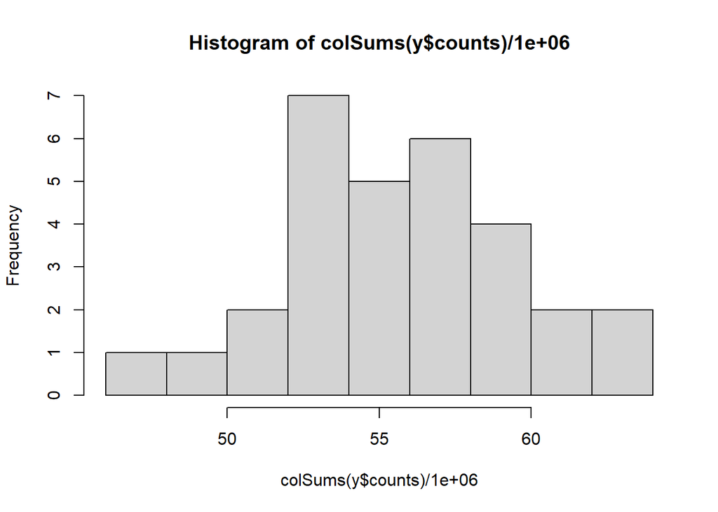

```r
rownames(y$samples) <- metadata_subset$specimenName
# background
expr.genes <- unique(y$genes$symbol)

#### 3. Data exploration, looking at the librarysize ####
# an outlier sample can be removed
# library size distribution
# you get a library size per sample and check this
hist(colSums(y$counts)/1e6, breaks=10)
```

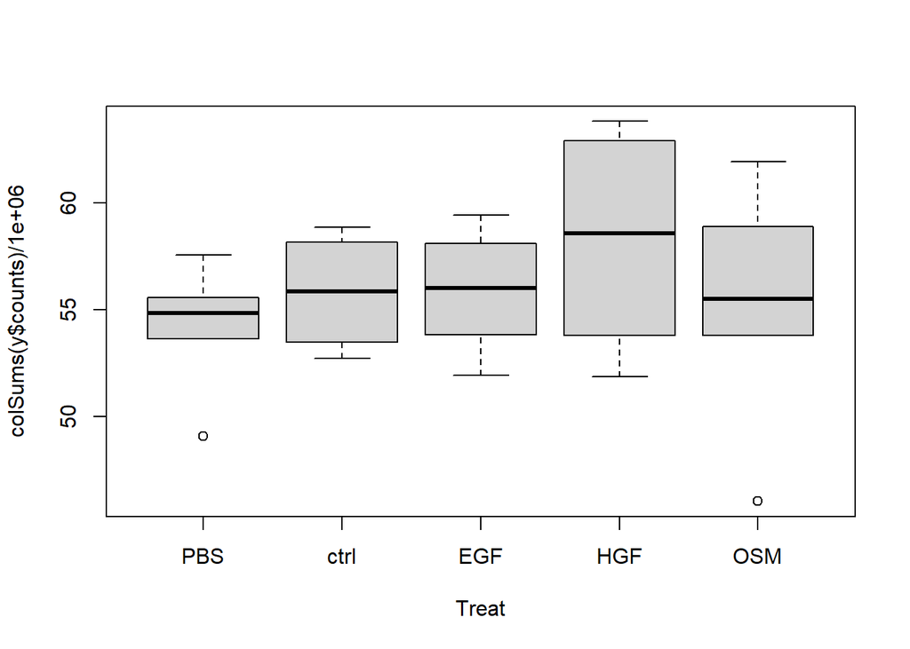

```r
boxplot(colSums(y$counts)/1e6 ~ Treat)
```

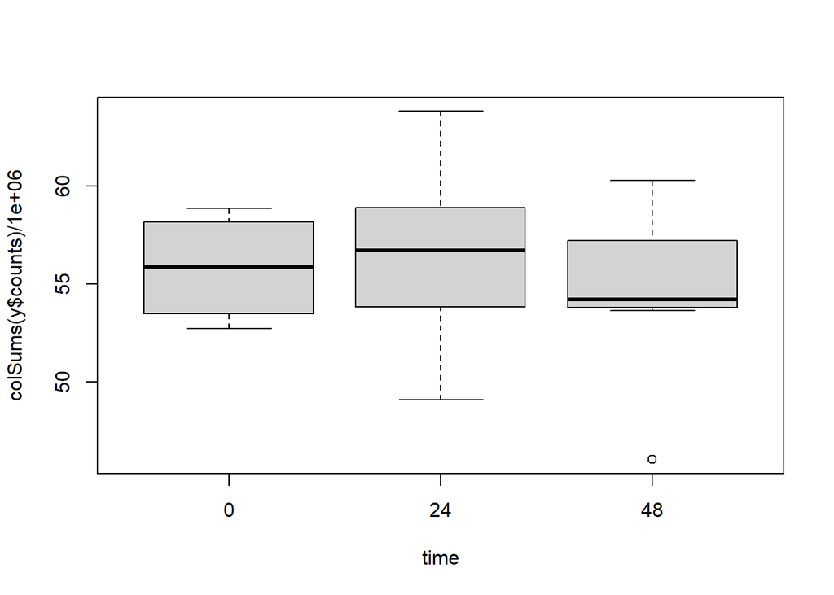

```r
boxplot(colSums(y$counts)/1e6 ~ time)
```

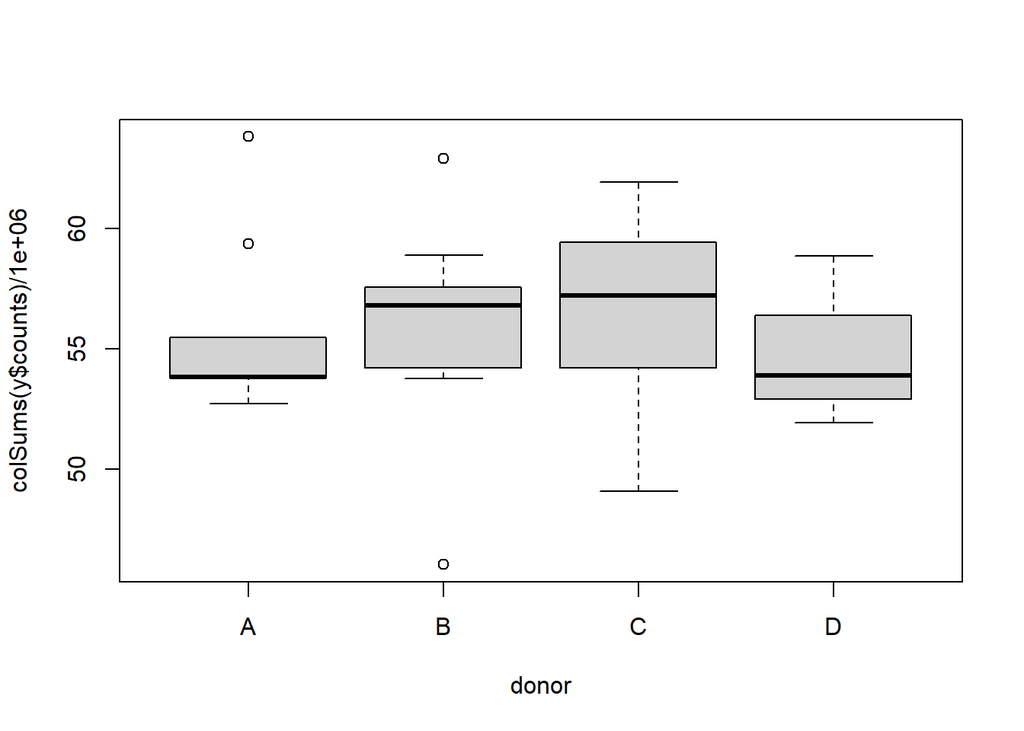

```r
boxplot(colSums(y$counts)/1e6 ~ donor)
```

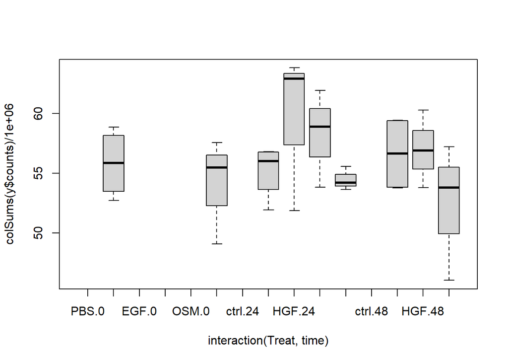

```r
boxplot(colSums(y$counts)/1e6 ~ interaction(Treat, time))
```

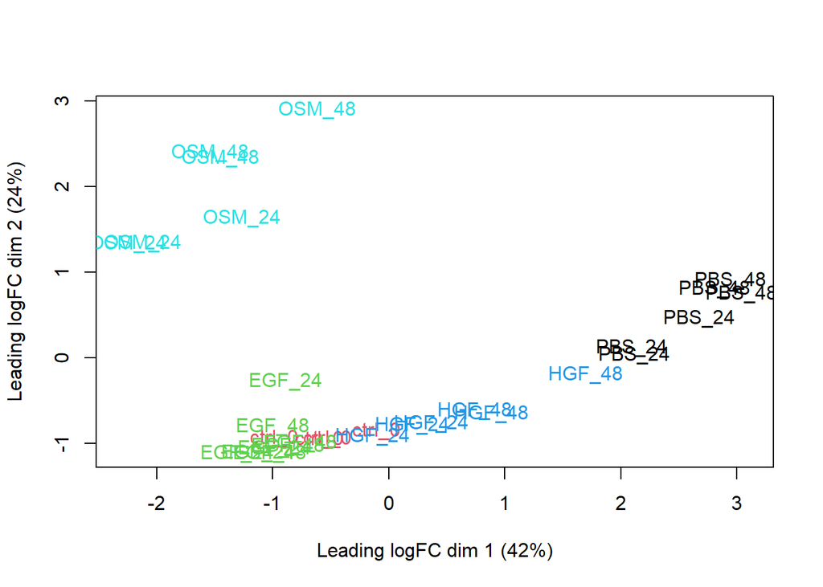

```r
# MDS plot
plotMDS(y, labels = group, col = as.numeric(Treat))
```

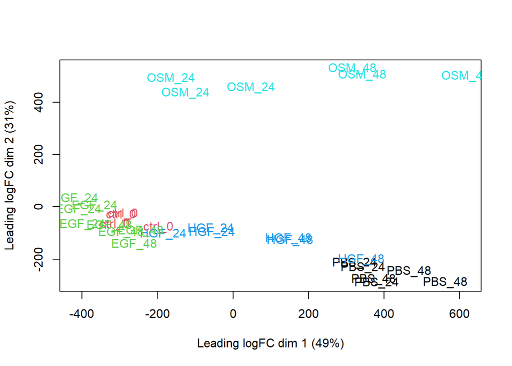

```r
# Preprocess counts, estimate dispersion
y <- calcNormFactors(y)
# What is the effect of the normalization?
plotMDS(cpm(y), labels = group, col = as.numeric(Treat))
```

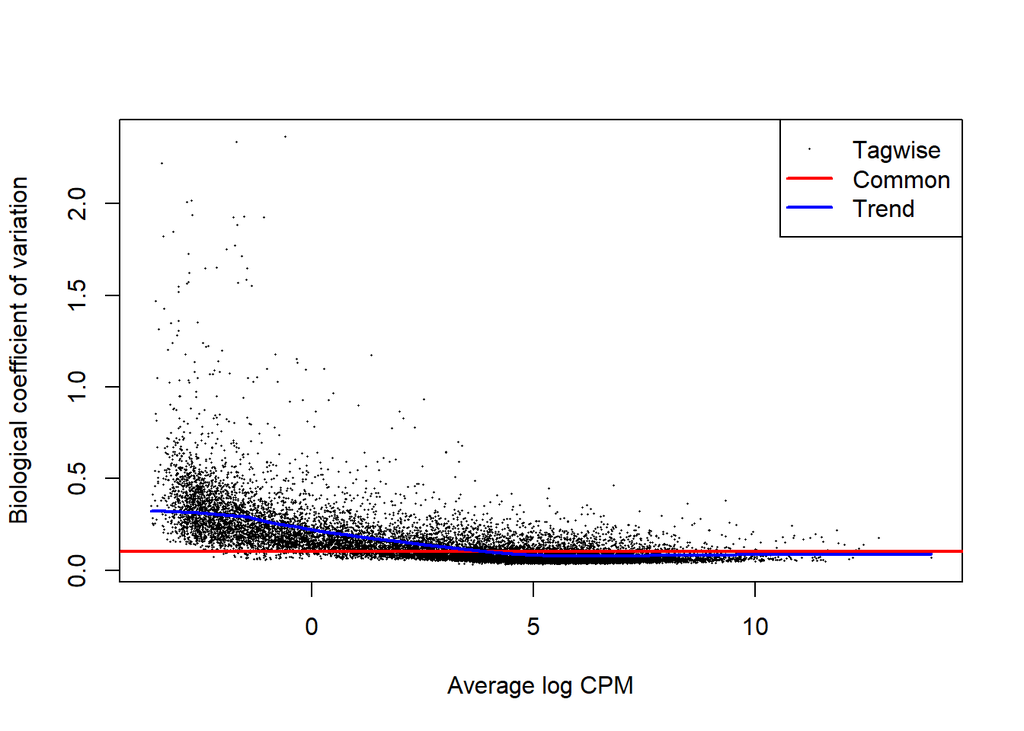

```r
y <- estimateDisp(y, design)
plotBCV(y)
```

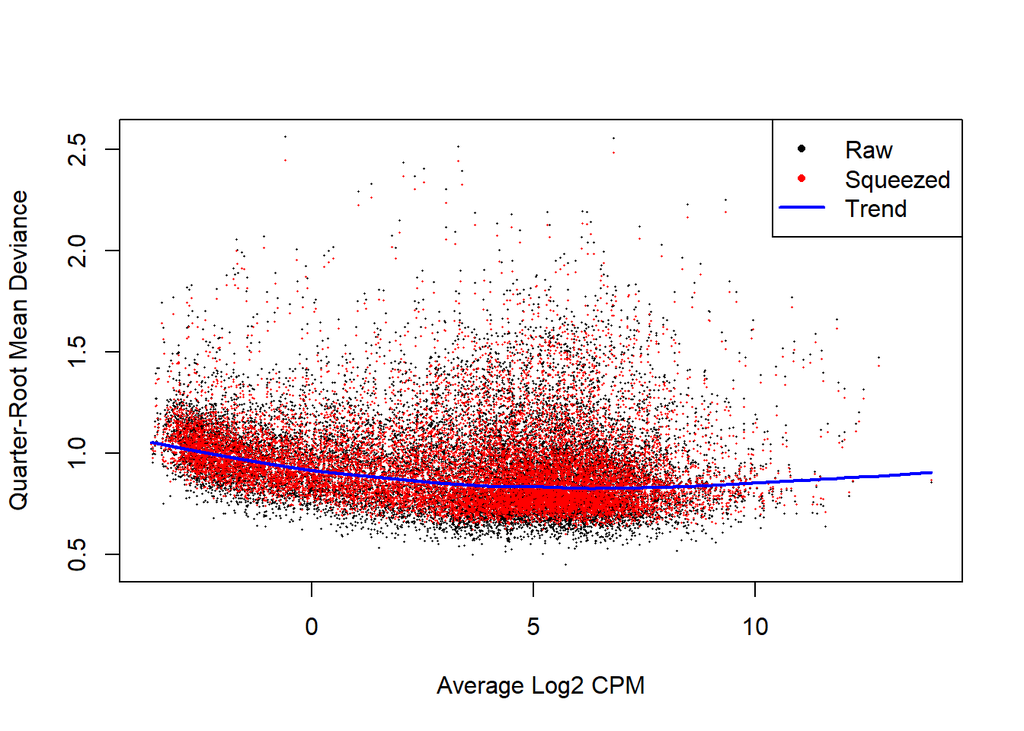

```r
# Fit the model
fit <- glmQLFit(y, design, robust = TRUE)
plotQLDisp(fit)
```

```r
de.genes <- list()

for (i in 1:length(contr)){
  print(names(contr)[[i]])
  qlf <- glmQLFTest(fit, contrast=contr[[i]])
  is.de <- decideTestsDGE(qlf,p.value = 0.05, lfc = 1.5)
  print(summary(is.de))
  diffexp <- as.tibble(topTags(qlf, n = Inf, p.value = 1)$table) %>%
      dplyr::select(logFC, FDR, symbol) %>%
      dplyr::rename(lfc = logFC, qval = FDR, gene = symbol) %>%
      na.omit()
  de.genes[[i]] <- list("diffexp" = diffexp,
                          "from" = c(str_sub(names(contr)[i],
                                           start = 1, end = 3)),
                          "name" = c(names(contr)[i]),
                          "type" = "primary") # we still don´t know what the criterion was for type
  }
```

```
## [1] "EGF_24h"
##        1*EGF_24 -1*PBS_24
## Down                 1513
## NotSig              13771
## Up                   1086
```

```
## [1] "HGF_24h"
##        1*HGF_24 -1*PBS_24
## Down                  519
## NotSig              15266
## Up                    585
## [1] "OSM_24h"
##        1*OSM_24 -1*PBS_24
## Down                 1501
## NotSig              13571
## Up                   1298
## [1] "EGF_48h"
##        1*EGF_48 -1*PBS_48
## Down                 1459
## NotSig              13773
## Up                   1138
## [1] "HGF_48h"
##        1*HGF_48 -1*PBS_48
## Down                  242
## NotSig              15618
## Up                    510
## [1] "OSM_48h"
##        1*OSM_48 -1*PBS_48
## Down                  969
## NotSig              14213
## Up                   1188
```

```r
names(de.genes) <- names(contr)


# sanity check
str(de.genes)
```

```
## List of 6
##  $ EGF_24h:List of 4
##   ..$ diffexp: tibble [16,370 x 3] (S3: tbl_df/tbl/data.frame)
##   .. ..$ lfc : num [1:16370] -1.46 -1.9 -2.71 -1.8 -2.91 ...
##   .. ..$ qval: num [1:16370] 8.80e-14 2.71e-13 3.54e-13 3.54e-13 3.54e-13 ...
##   .. ..$ gene: chr [1:16370] "UBL3" "FOXO3" "GPC6" "HADHB" ...
##   ..$ from   : chr "EGF"
##   ..$ name   : chr "EGF_24h"
##   ..$ type   : chr "primary"
##  $ HGF_24h:List of 4
##   ..$ diffexp: tibble [16,370 x 3] (S3: tbl_df/tbl/data.frame)
##   .. ..$ lfc : num [1:16370] 2.18 -2.01 1.61 1.19 3.09 ...
##   .. ..$ qval: num [1:16370] 8.82e-10 8.82e-10 8.84e-10 8.84e-10 8.84e-10 ...
##   .. ..$ gene: chr [1:16370] "STIL" "GPC6" "PARP2" "HNRNPA2B1" ...
##   ..$ from   : chr "HGF"
##   ..$ name   : chr "HGF_24h"
##   ..$ type   : chr "primary"
##  $ OSM_24h:List of 4
##   ..$ diffexp: tibble [16,370 x 3] (S3: tbl_df/tbl/data.frame)
##   .. ..$ lfc : num [1:16370] 3.96 9.4 5.01 -2.36 -3.81 ...
##   .. ..$ qval: num [1:16370] 3.52e-19 3.52e-19 9.47e-19 1.33e-18 1.24e-17 ...
##   .. ..$ gene: chr [1:16370] "WWC1" "SERPINB4" "SERPINA1" "TBC1D8" ...
##   ..$ from   : chr "OSM"
##   ..$ name   : chr "OSM_24h"
##   ..$ type   : chr "primary"
##  $ EGF_48h:List of 4
##   ..$ diffexp: tibble [16,370 x 3] (S3: tbl_df/tbl/data.frame)
##   .. ..$ lfc : num [1:16370] -3.29 -3.4 -2.37 1.77 -2 ...
##   .. ..$ qval: num [1:16370] 1.58e-14 1.58e-14 3.82e-14 3.82e-14 4.61e-14 ...
##   .. ..$ gene: chr [1:16370] "H1-2" "COL6A1" "FLRT3" "FUS" ...
##   ..$ from   : chr "EGF"
##   ..$ name   : chr "EGF_48h"
##   ..$ type   : chr "primary"
##  $ HGF_48h:List of 4
##   ..$ diffexp: tibble [16,370 x 3] (S3: tbl_df/tbl/data.frame)
##   .. ..$ lfc : num [1:16370] 3.53 -1.23 4.69 1.09 4.06 ...
##   .. ..$ qval: num [1:16370] 5.31e-11 6.10e-10 6.10e-10 6.10e-10 6.10e-10 ...
##   .. ..$ gene: chr [1:16370] "SCARA3" "DGKD" "PIMREG" "SCCPDH" ...
##   ..$ from   : chr "HGF"
##   ..$ name   : chr "HGF_48h"
##   ..$ type   : chr "primary"
##  $ OSM_48h:List of 4
##   ..$ diffexp: tibble [16,370 x 3] (S3: tbl_df/tbl/data.frame)
##   .. ..$ lfc : num [1:16370] 6.9 4 9.45 4.1 11.39 ...
##   .. ..$ qval: num [1:16370] 1.86e-20 1.27e-19 1.27e-19 8.63e-19 1.95e-18 ...
##   .. ..$ gene: chr [1:16370] "SERPINA1" "WWC1" "SERPINB4" "HMGB3" ...
##   ..$ from   : chr "OSM"
##   ..$ name   : chr "OSM_48h"
##   ..$ type   : chr "primary"
```

```r
tail(de.genes$EGF_24h$table)
```

```r
DE_EGF_24 <- de.genes$EGF_24h$diffexp  %>% filter((abs(lfc) >= 1.5) & (qval <= 0.05))
DE_EGF_48 <- de.genes$EGF_48h$diffexp  %>% filter((abs(lfc) >= 1.5) & (qval <= 0.05))
DE_OSM_24 <- de.genes$OSM_24h$diffexp  %>% filter((abs(lfc) >= 1.5) & (qval <= 0.05))
DE_OSM_48 <- de.genes$OSM_48h$diffexp  %>% filter((abs(lfc) >= 1.5) & (qval <= 0.05))
DE_HGF_24 <- de.genes$HGF_24h$diffexp  %>% filter((abs(lfc) >= 1.5) & (qval <= 0.05))
DE_HGF_48 <- de.genes$HGF_48h$diffexp  %>% filter((abs(lfc) >= 1.5) & (qval <= 0.05))
```

We now have potential ground truth data sets that we can use now for the validation of NN. But do the DE genes occur in NN and as relevant target genes in the GRN?

```r
# let's do the overlap with the DE genes for EGF 24, still way too many
targets.DE <- de.genes$EGF_24h$diffexp$gene
length(targets.DE)
```

```
## [1] 16370
```

```r
length(intersect(targets.NN, targets.DE)) # very high
```

```
## [1] 15695
```

```r
length(intersect(targets.GRN, targets.DE)) # very high
```

```
## [1] 1178
```

```r
# what if we are more stringent? who knows ...
```

## Check 5: Run a regular NN validation

Let’s go back to the validation vignette of NN and check how we can do it with appropriate thresholding of the DE.

We see that it is a list, named with the GSEnumber_ligand_add. It contains the from, the name and the type (with primary and secondary). We should ask about that. The diffexp contains lfc, qval (fdr-correction) and gene that have not been filtered. So the function from NicheNet chooses thresholds, in the original case the absolute value of the logFC exceeds 1 and the FDR-corrected p-value is smaller than 0.1. We are making it more stringent to logFC exceeds 1.5 and the FDR-corrected p-value is smaller than 0.05.

```r
# adjust the function to make it more stringent (q<=0.05, abs(lfc)) >= 2
convert_expression_settings_evaluation <-
  function(setting){
    if (!is.character(setting$from) | !is.character(setting$name))
        stop("setting$from and setting$name should be character vectors")
    if (!is.data.frame(setting$diffexp))
        stop("setting$diffexp should be data frame")
    if (is.null(setting$diffexp$lfc) | is.null(setting$diffexp$gene) |
        is.null(setting$diffexp$qval))
        stop("setting$diffexp should contain the variables 'lfc', 'qval' and 'diffexp'")
    requireNamespace("dplyr")
    diffexp_df = setting$diffexp %>% mutate(diffexp = (abs(lfc) >= 1.5) & (qval <= 0.05))
    diffexp_vector = diffexp_df$diffexp
    names(diffexp_vector) = diffexp_df$gene
    diffexp_vector = diffexp_vector[unique(names(diffexp_vector))]
    if ((diffexp_vector %>% sum) == 0) {
        print(setting$name)
        warning("No differentially expressed genes, remove this expression dataset")
    }
    return(list(name = setting$name, from = setting$from, response = diffexp_vector))
  }

# The ligand treatment expression datasets used for validation can be downloaded from Zenodo:
expression_settings_validation <- readRDS(url("https://zenodo.org/record/8010790/files/expression_settings"))

str(expression_settings_validation[[1]])
```

```
## List of 4
##  $ diffexp: tibble [17,330 x 3] (S3: tbl_df/tbl/data.frame)
##   ..$ lfc : num [1:17330] 3.36 3.23 3.2 3.08 -2.89 ...
##   ..$ qval: num [1:17330] 8.79e-06 1.02e-03 9.59e-05 8.47e-05 2.47e-03 ...
##   ..$ gene: Named chr [1:17330] "NOG" "DLX2" "INSYN2B" "S1PR5" ...
##   .. ..- attr(*, "names")= chr [1:17330] "9241" "1746" "100131897" "53637" ...
##  $ from   : Named chr "BMP4"
##   ..- attr(*, "names")= chr "Bmp4"
##  $ name   : chr "bmp4_Bmp4"
##  $ type   : chr "primary"
```

```r
str(de.genes[[1]])
```

```
## List of 4
##  $ diffexp: tibble [16,370 x 3] (S3: tbl_df/tbl/data.frame)
##   ..$ lfc : num [1:16370] -1.46 -1.9 -2.71 -1.8 -2.91 ...
##   ..$ qval: num [1:16370] 8.80e-14 2.71e-13 3.54e-13 3.54e-13 3.54e-13 ...
##   ..$ gene: chr [1:16370] "UBL3" "FOXO3" "GPC6" "HADHB" ...
##  $ from   : chr "EGF"
##  $ name   : chr "EGF_24h"
##  $ type   : chr "primary"
```

```r
# First these validation data sets need to be converted to the right format, makes it in to a logical vector if it is DE or not

settings <- de.genes%>%
  lapply(convert_expression_settings_evaluation)
str(settings[[1]])
```

```
## List of 3
##  $ name    : chr "EGF_24h"
##  $ from    : chr "EGF"
##  $ response: Named logi [1:16370] FALSE TRUE TRUE TRUE TRUE TRUE ...
##   ..- attr(*, "names")= chr [1:16370] "UBL3" "FOXO3" "GPC6" "HADHB" ...
```

```r
# 16431 genes are checked to be expressed or not, so the entire list without filter is needed for validation? 10 more genes than expected
settings <- settings %>% discard(~length(.$from) > 1)

# Evaluate transcriptional response prediction on every dataset
performances <- settings %>% lapply(evaluate_target_prediction, ligand_target_matrix) %>% bind_rows()

# Visualize some classification evaluation metrics showing the target gene prediction performance
performances <- performances %>% dplyr::select(-aupr, -auc_iregulon,-pearson_log_pval,-spearman_log_pval ,-sensitivity_roc, -specificity_roc) %>% gather(key = scorename, value = scorevalue, auroc:spearman)
```

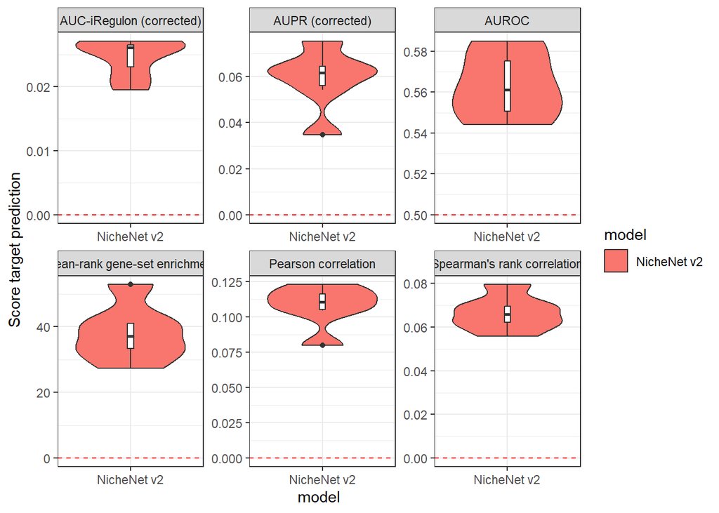

```r
scorelabels <- c(auroc="AUROC", aupr_corrected="AUPR (corrected)", auc_iregulon_corrected = "AUC-iRegulon (corrected)",pearson = "Pearson correlation", spearman = "Spearman's rank correlation",mean_rank_GST_log_pval = "Mean-rank gene-set enrichment")

scorerandom <- c(auroc=0.5, aupr_corrected=0, auc_iregulon_corrected = 0, pearson = 0, spearman = 0,mean_rank_GST_log_pval = 0) %>% data.frame(scorevalue=.) %>% rownames_to_column("scorename")

performances %>%
  mutate(model = "NicheNet v2") %>%
  ggplot() +
  geom_violin(aes(model, scorevalue, group=model, fill = model)) +
  geom_boxplot(aes(model, scorevalue, group = model),width = 0.05) +
  scale_y_continuous("Score target prediction") +
  facet_wrap(~scorename, scales = "free", labeller=as_labeller(scorelabels)) +
  geom_hline(aes(yintercept=scorevalue), data=scorerandom, linetype = 2, color = "red") +
  theme_bw()
```

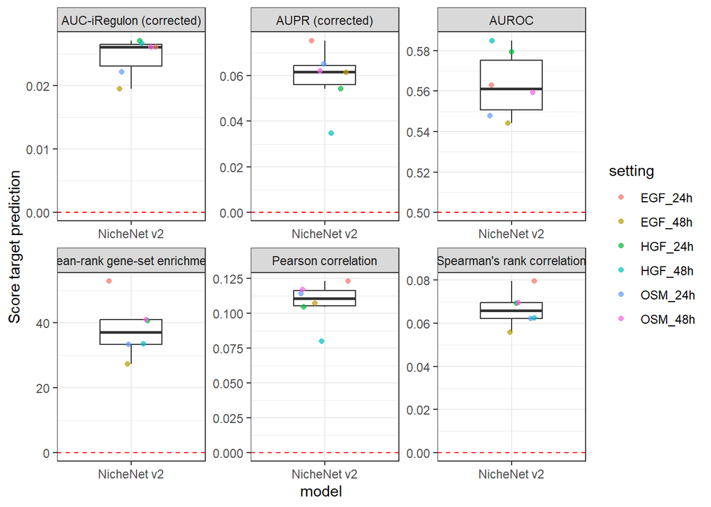

```r
performances %>%
  mutate(model = "NicheNet v2") %>%
  ggplot() +
  geom_boxplot(aes(model, scorevalue, group = model), width = 0.5, outlier.shape = NA) +
  geom_point(aes(model, scorevalue, color = setting), position = position_jitter(width = 0.2), alpha = 0.7) +
  scale_y_continuous("Score target prediction") +
  facet_wrap(~scorename, scales = "free", labeller = as_labeller(scorelabels)) +
  geom_hline(aes(yintercept = scorevalue), data = scorerandom, linetype = 2, color = "red") +
  theme_bw()
```

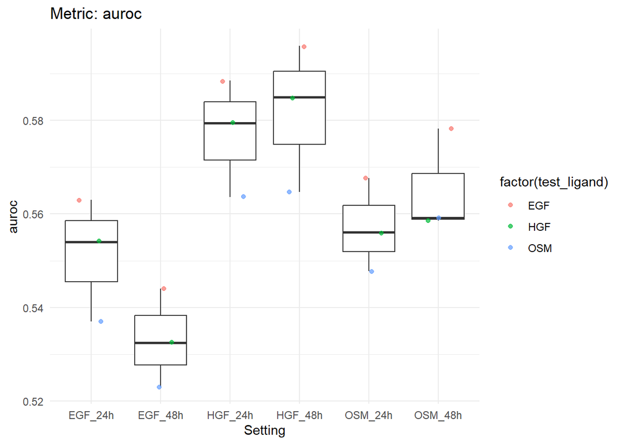

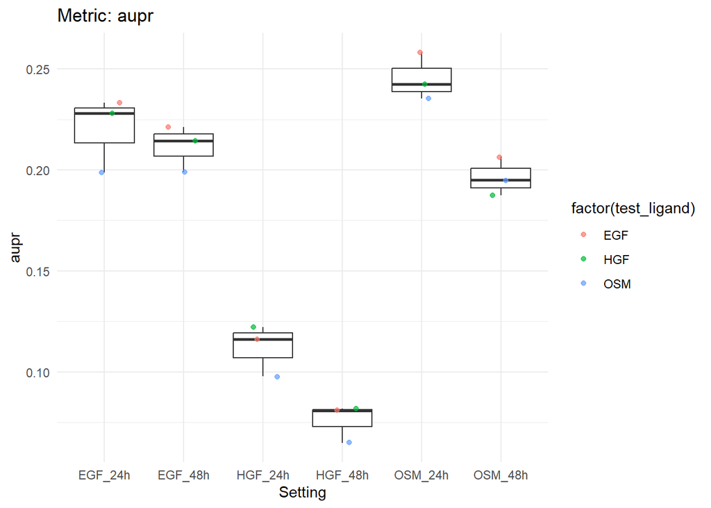

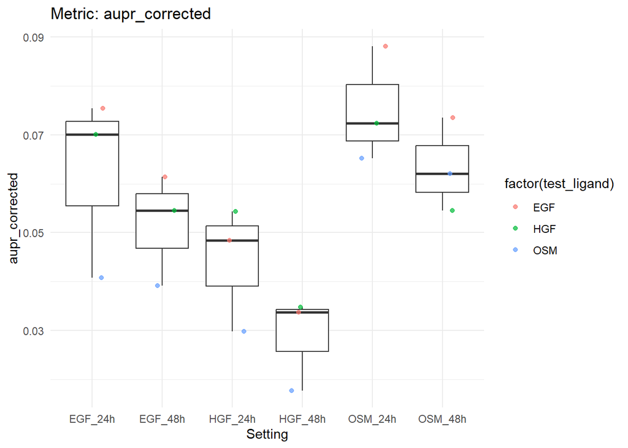

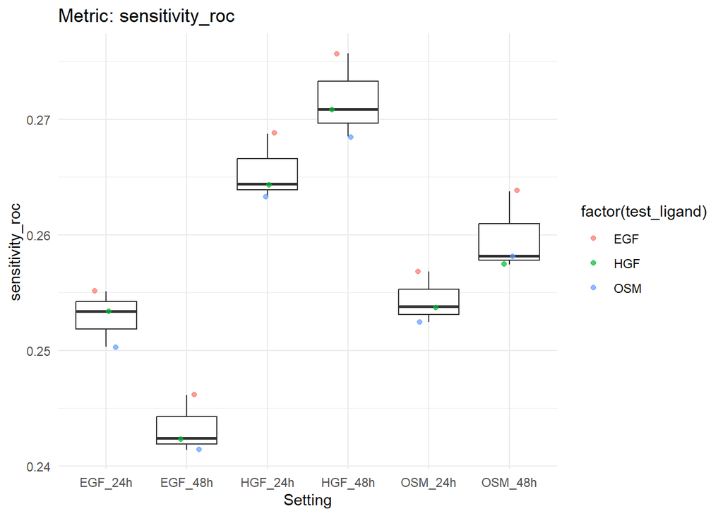

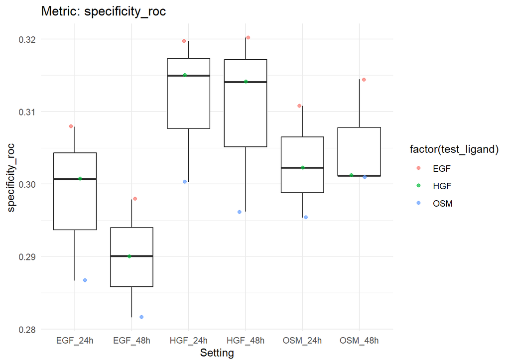

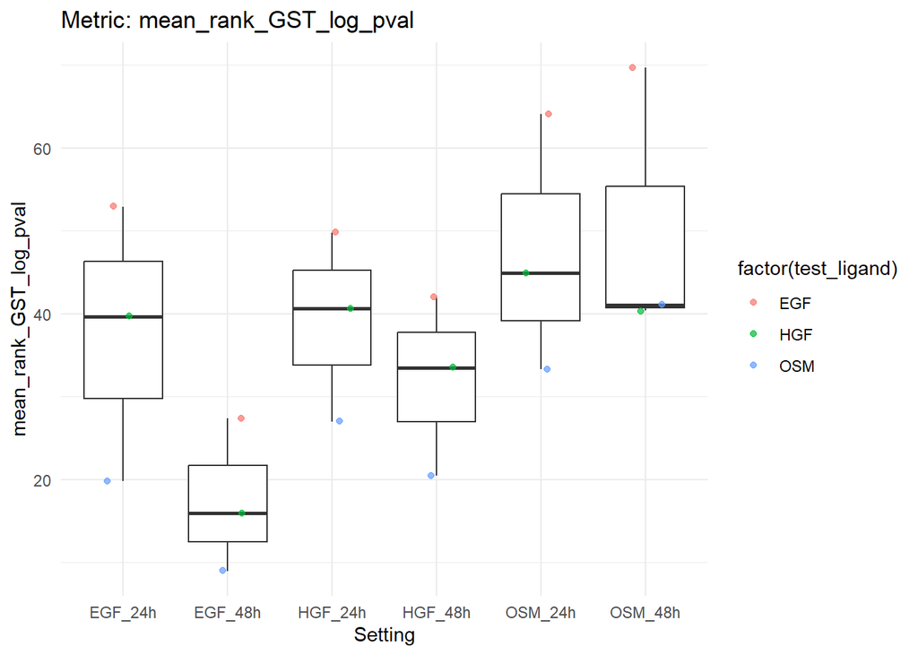

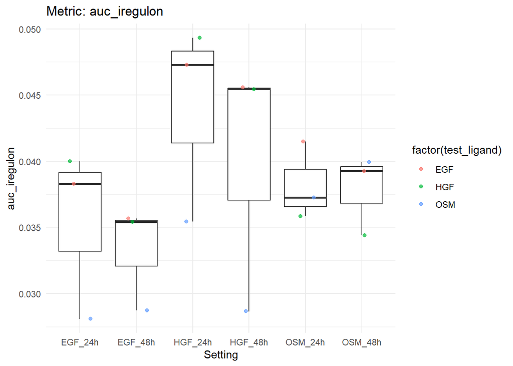

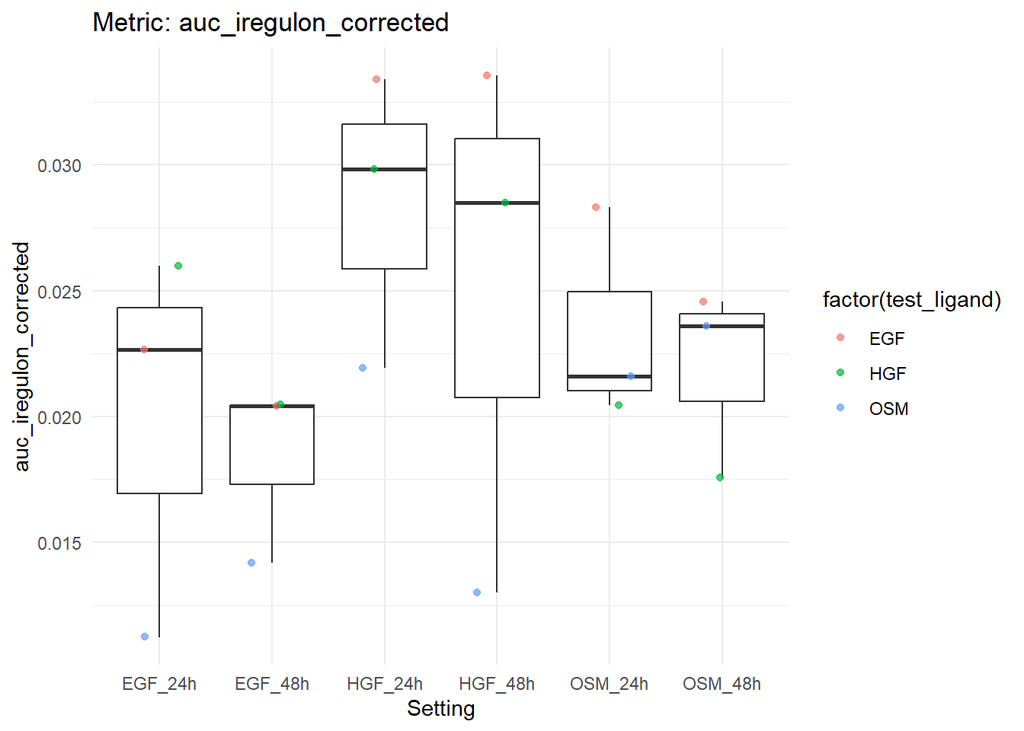

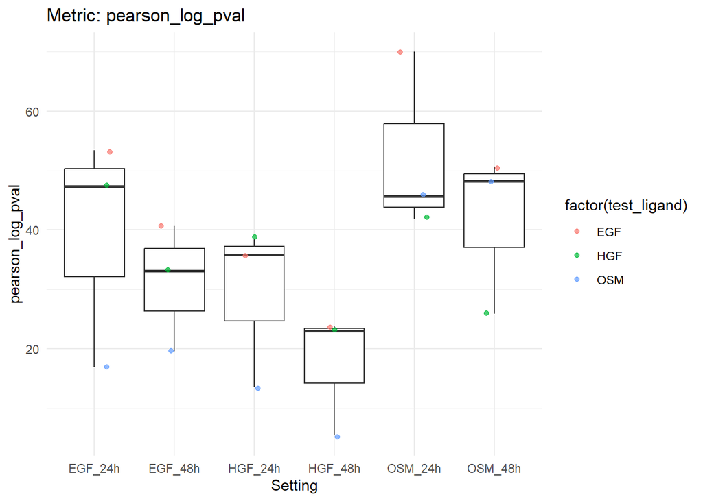

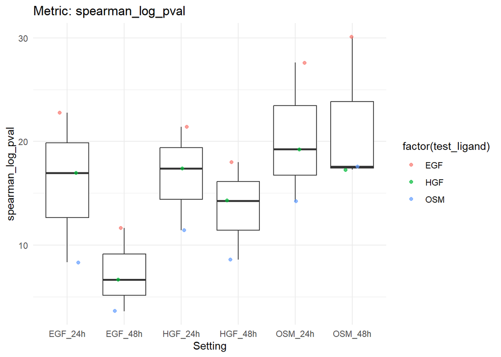

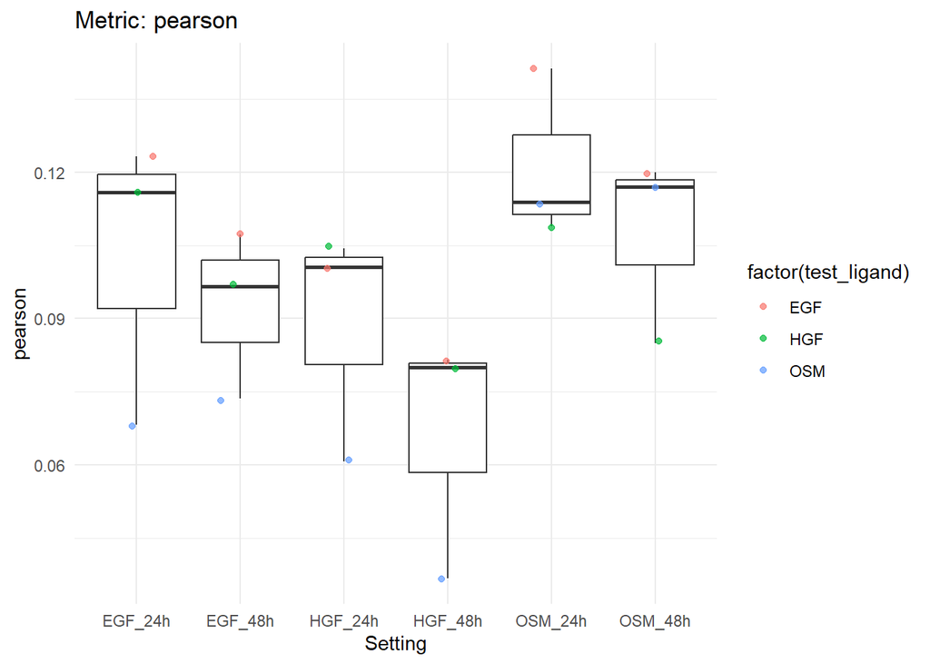

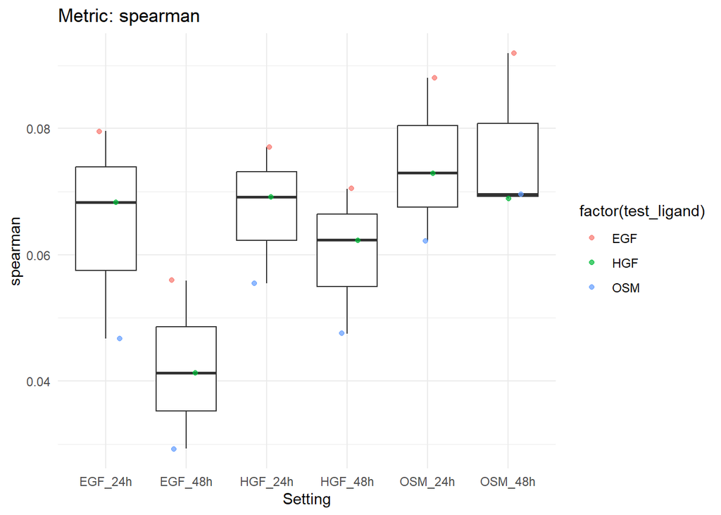

```r
# How good are the ligand activities?
all_ligands <- settings %>% extract_ligands_from_settings(combination = FALSE) %>% unlist()
settings_ligand_prediction <- settings %>% convert_settings_ligand_prediction(all_ligands = all_ligands, validation = TRUE)

# infer ligand importances: for all ligands of interest, we assess how well a ligand explains the differential expression in a specific datasets (and we do this for all datasets).
ligand_importances <- settings_ligand_prediction %>% lapply(get_single_ligand_importances,ligand_target_matrix) %>% bind_rows()

# Look at predictive performance of single/individual importance measures to predict ligand activity: of all ligands tested, the ligand that is truly active in a dataset should get the highest activity score (i.e. best target gene prediction performance)

# Replace infinite values with 10000
ligand_importances <- ligand_importances %>% mutate(across(ends_with("log_pval"), ~ifelse(is.infinite(.x), 10000, .x)))

# Get available metrics from the data
exclude_columns <- c("setting", "test_ligand", "ligand")
metrics <- colnames(ligand_importances)[!(colnames(ligand_importances) %in% exclude_columns)]

plots <- lapply(metrics, function(metric) {
  ggplot(ligand_importances, aes(x = setting, y = .data[[metric]])) +
    geom_boxplot() +
    geom_jitter(data = ligand_importances, aes(color = factor(test_ligand)), width = 0.2, alpha = 0.7) +
    labs(title = paste("Metric:", metric),
         x = "Setting",
         y = metric) +
    theme_minimal() +
    scale_color_discrete()  # Add color scale legend
})
plots
```